# Hurricane Landfall Analysis

## Selected Hurricane:

In this assignment, our group selected hurricane with ID: “Harvey-2017”.

## Selected Deliverable Format:

For this assignment, we selected an document for the deliverable format, since an document is good for record purposes and is each to read.

## Task One:

For analyzing this hurricane dataset, we draw a series of maps for different purposes using “hurricaneexposure” package in R.

First, we draw a map to show the track of the hurricane:

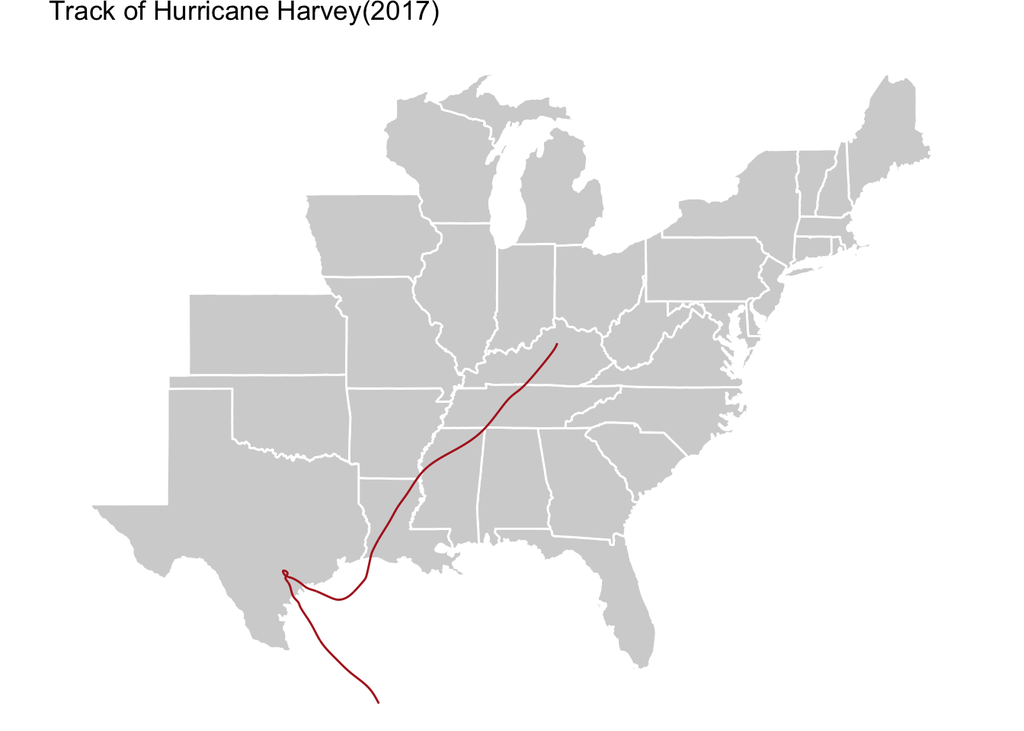

As the red line shown on the map, Hurricane Harvey was landfall on Texas and Louisiana, then head towards the middle of the United States.

Then we plotted the closest distance between the storm and each county. Counties with darker colors are closer to the center of the hurricane:

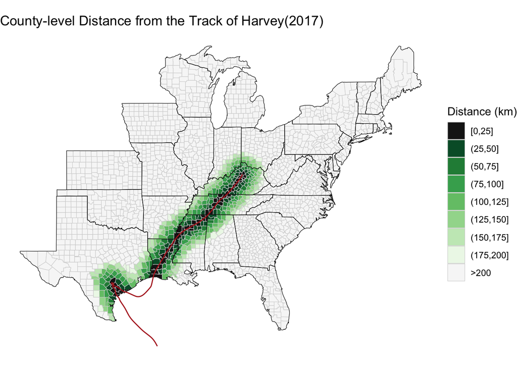

The third map shown below plots the wind speed during the storm to each county. The hurricane logged in from Texas, where counties experienced the fastest wind speeds, followed by Louisiana. When the hurricane goes to the middle, the wind speed is not fast.

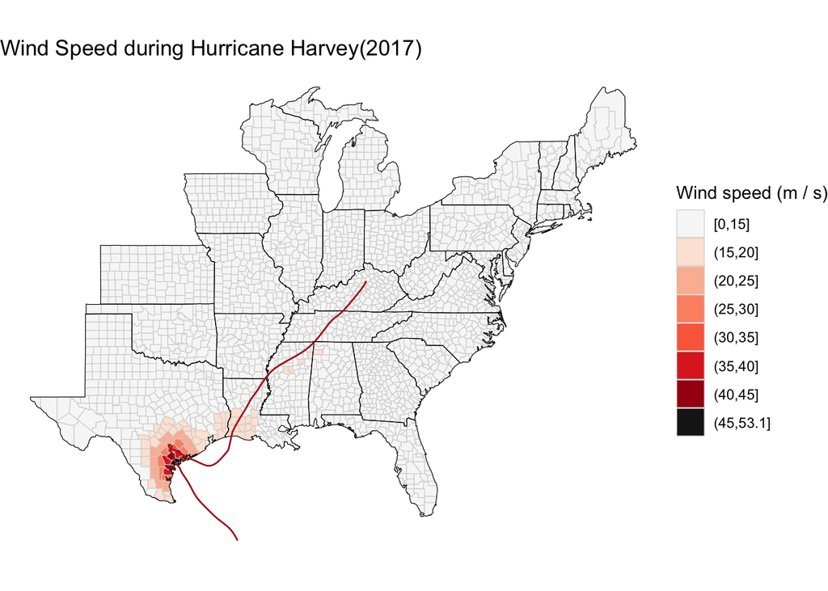

Next we drawn the counties where the hurricane wind speed exceeds 20m/s as follows. Painted counties are mostly concentrated in Texas, so the disasters and losses caused there are the most serious.

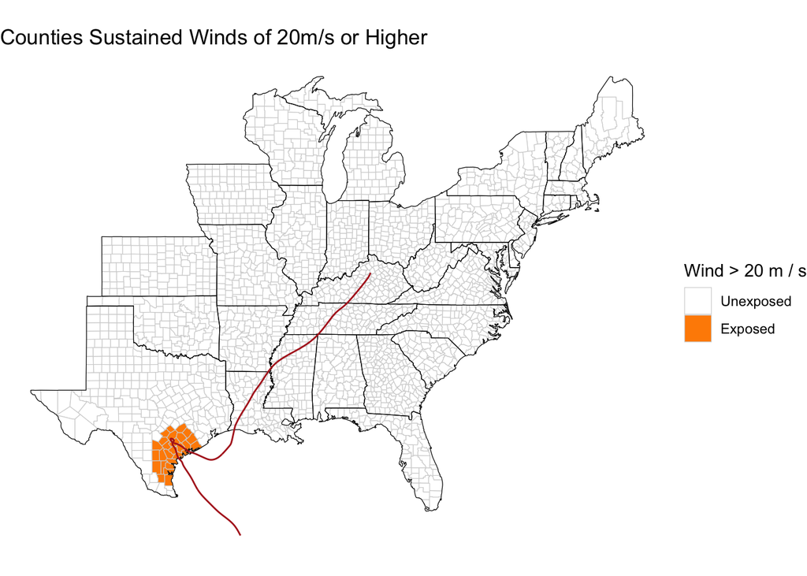

Our last map shown below plots counties for which a flood event was listed for Harvey(2017). Many areas in eastern Texas received large rainfall, causing unprecedented flooding.

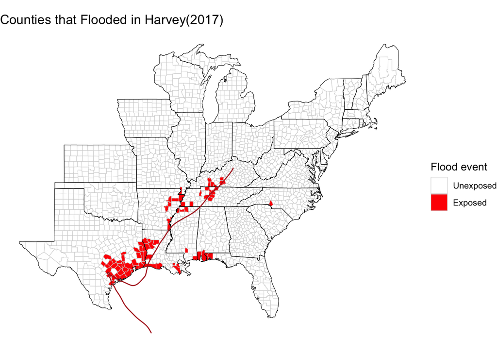

## Task Two:

In task two, we coorperated NOAA buoy data for analyzing selected hurricane “Harvey-2017”. In this hurricane’s report in NOAA website, “AL092017_Harvey.pdf”, which could be found in our github repo, 5 NOAA buoys are included: Station 42020, 42019, 42035, 42044 and 42045. These stations historical data dring year 2017 are put in the folder “buoy_data” which could be found in our github repo.

From the NOAA report about this hurricane, this hurricane happened during 08/17 to 09/01. We selected the data during 08/14 and 09/04, which adds three days both at the begining and in the end.

Two properties, air temperature and wave height, are analyzed during the selected period for the five related NOAA buoys:

### 1. Air Temperature

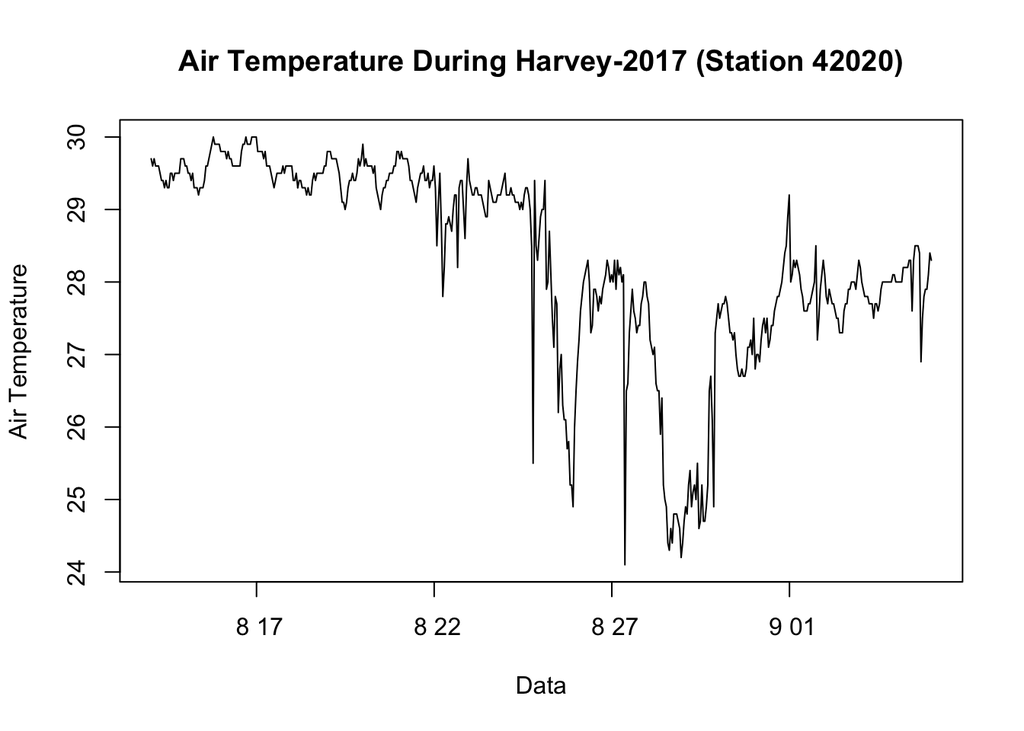

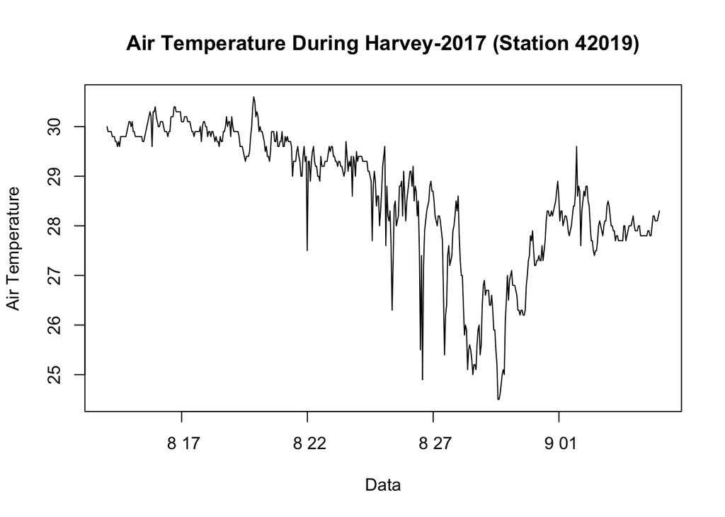

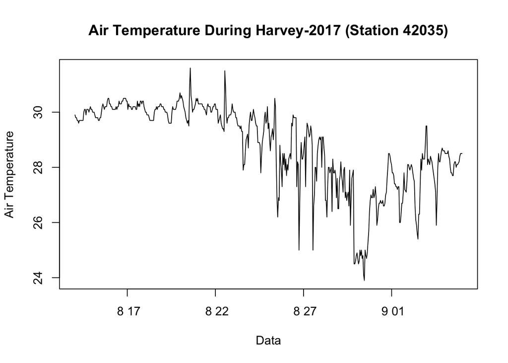

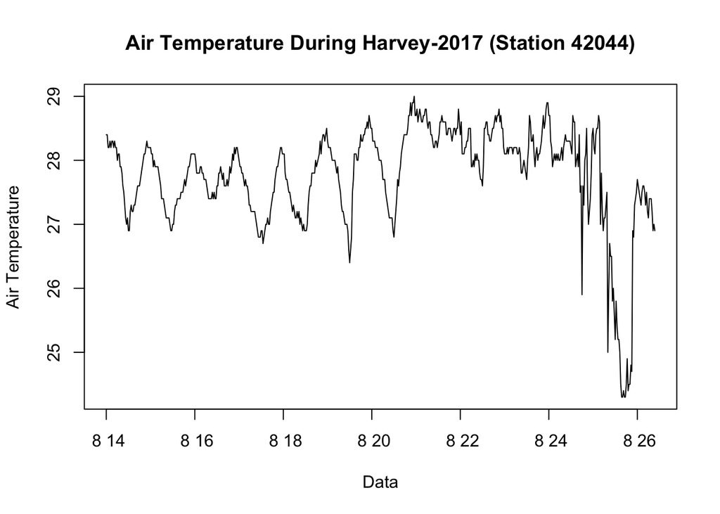

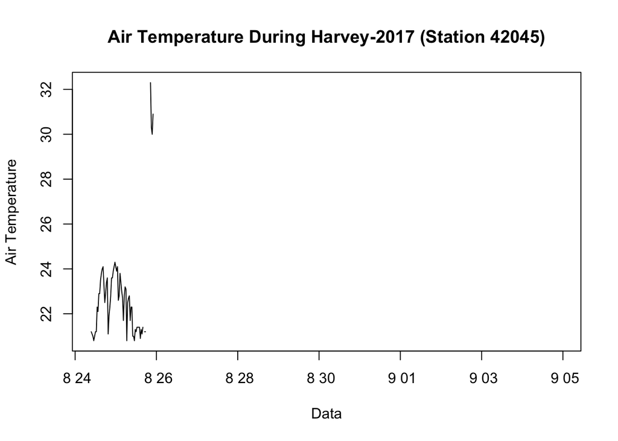

### 1. Wave Height

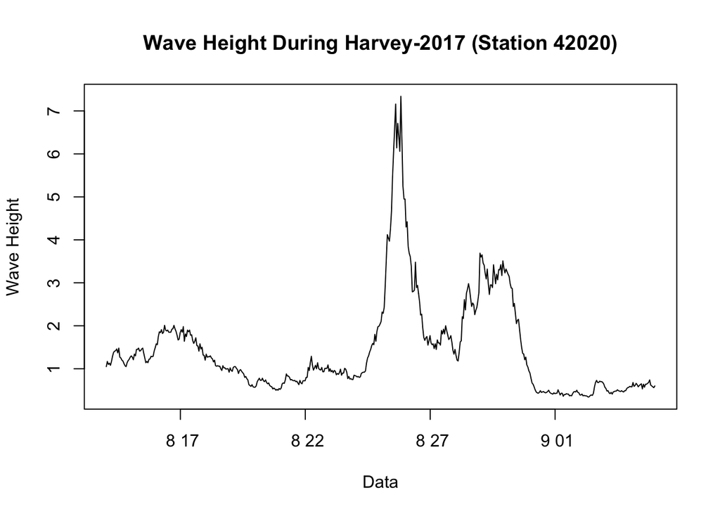

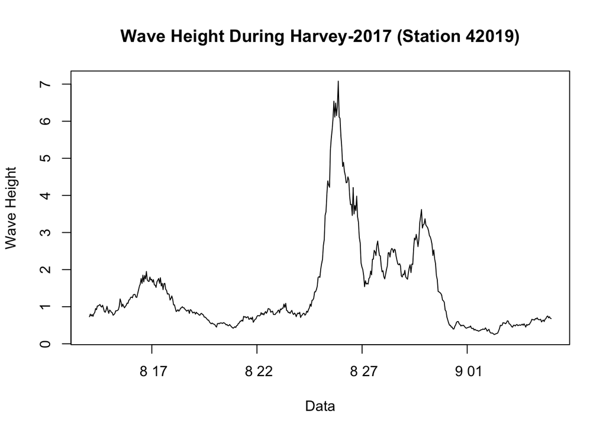

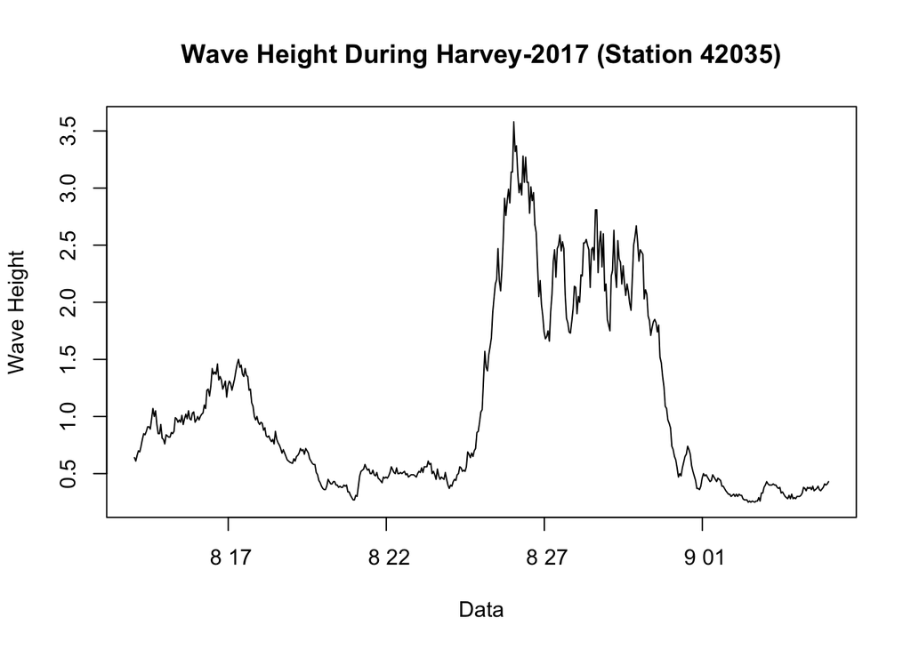

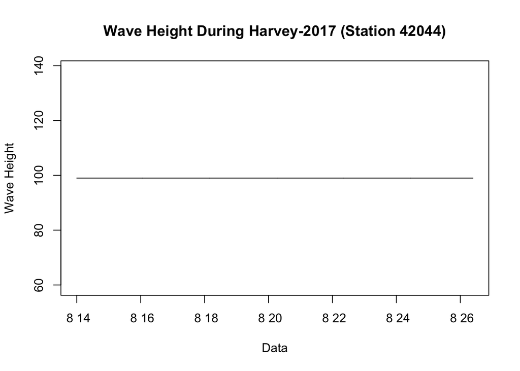

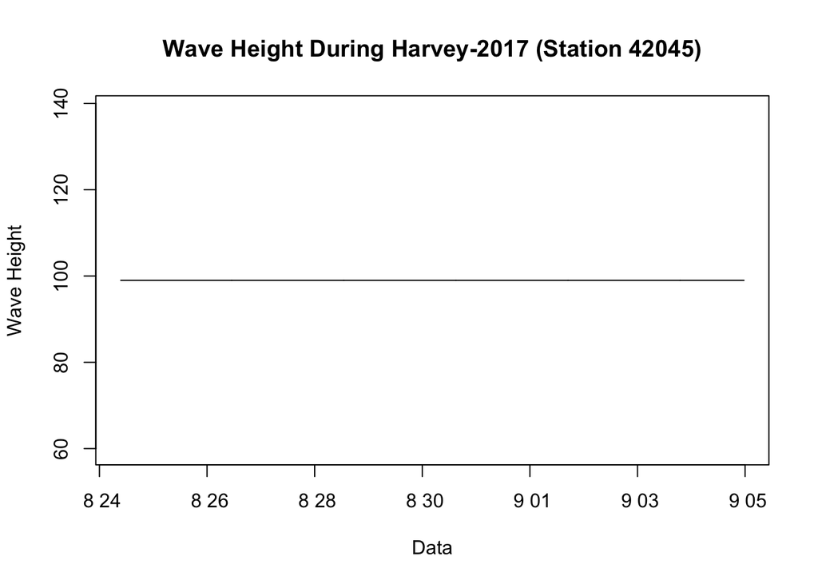

### 3. Discussion

From the above plots, we noticed that there are missing values from some buoy data. For example, the latter part of air temperature data of station 42044, most of air temperature data of station 42045 and all wave height data of both station 42044 and 42045. This fact may be caused by losing data records.